# GoBike Data Analysis

## Project: Communicate Data Findings

## Dataset Overview

This data set includes information about individual rides made in a bike-sharing system covering the greater San Francisco Bay area.

Questions that will be explored in this dataset are:

- What is the demographic of GoBikes userbase?
- What is the most popular station to pick up and/or return a bike?
- How long does the average trip take by gender?
- When are most trips taken in terms of time of day and day of the week?
- Does the above depend on if a user is a subscriber or customer?

#### What is the demographic of GoBikes userbase?

Males account for the majority of GoBike's total users. 74.6% of GoBike users are male. 23.3% of users are female. The remaining 2.1% are not identified.

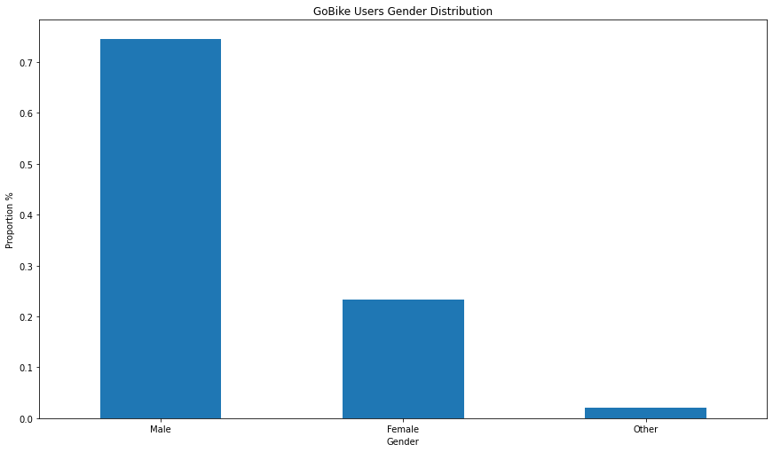

Over 100,000, or 65.2%, of GoBike users are in the age group of 18-35.

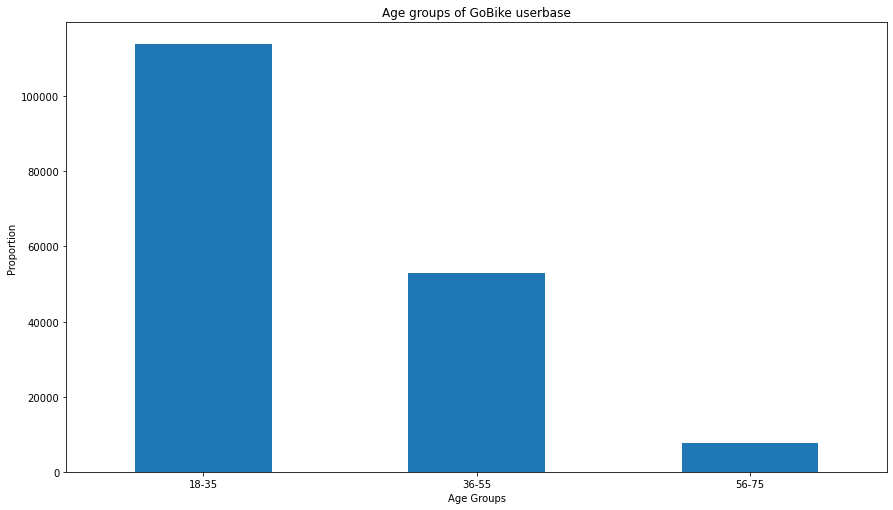

#### What is the most popular station to pick up and/or return a bike?

The most popular station users begin GoBike trips is at "Market St. at 10th St.".

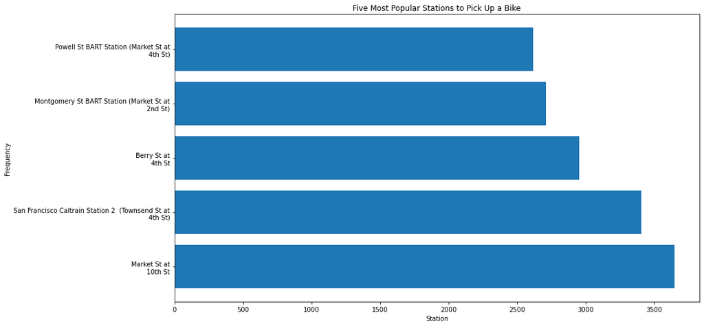

#### Least Popular Station to Start Trip

The least popular station users begin GoBike trips is at "16th St. Depot".

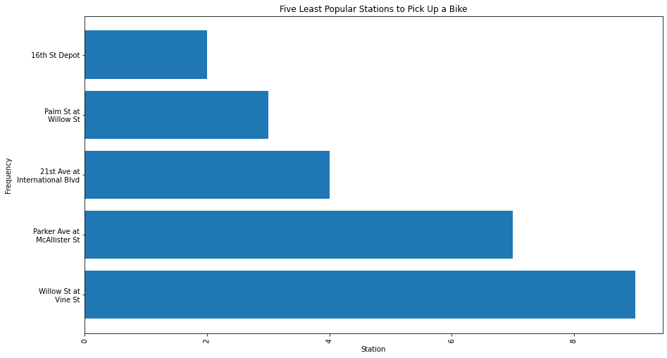

#### How long does the average trip take by gender?

The average trip duration for women is just over 12 minutes. The average trip duration for men is just over 10 minutes. Unfortunately users identifying as "Other" skews our results.

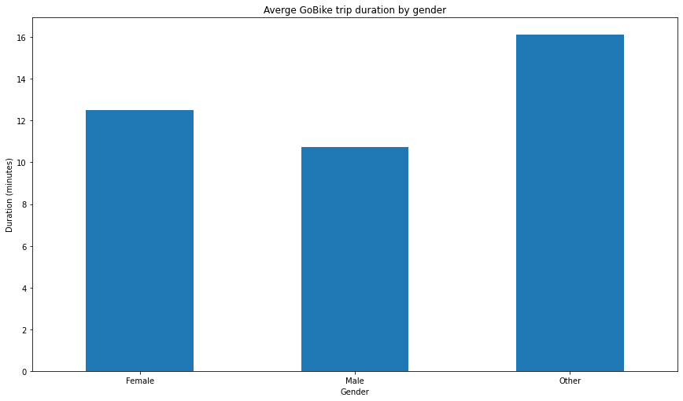

#### When are most trips taken in terms of time of day and day of the week?

GoBike users start trips most frequently at 8am and 5pm. Based on this data we can surmise most GoBike users are commuting to/from work.

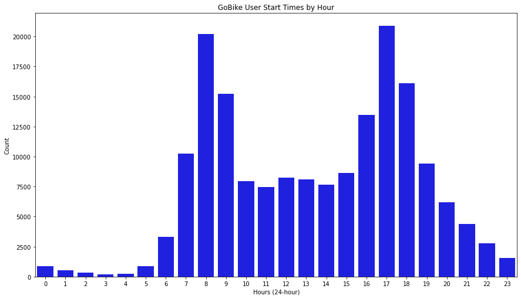

#### Most common day of the week for GoBike users

The most common day of the week for GoBike users to take a trip was Thursday. This confirms the conclusion that the bikes are predominately used during the week for commuting.

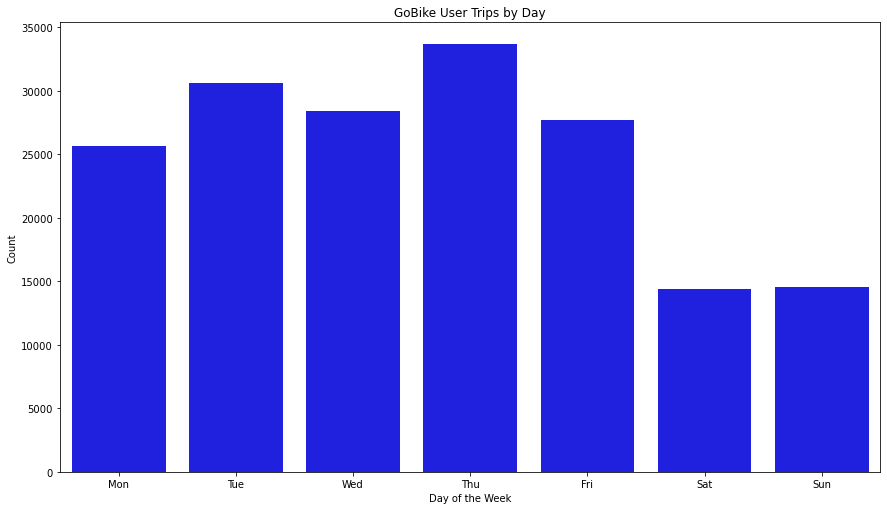

#### Do the above explorations depend on if a user is a subscriber or customer?

It appears as though the majority of subscribers to GoBike are male.

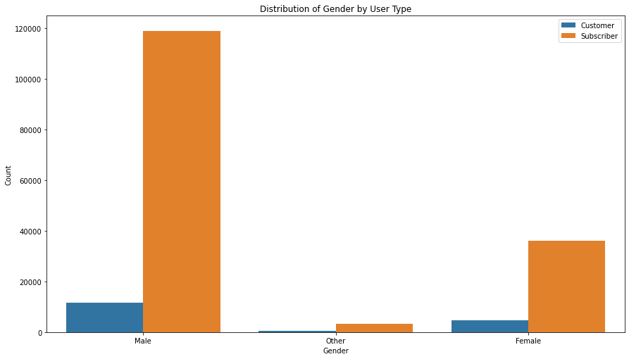

#### Age group by user type

The age group with the most amount of GoBike subscribers is between 18-35 years old.

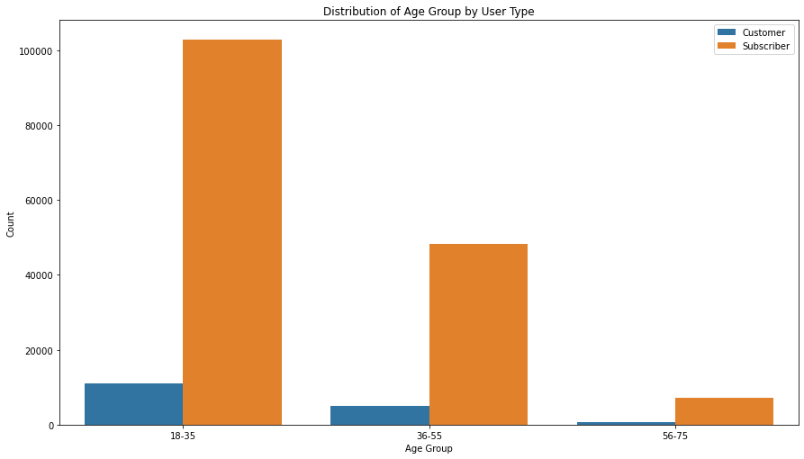

#### Trip duration by user type

The average duration of a customer trip is 21 minutes. This is higher than the subscriber average of 10 minutes. This could be due to more variability of customers who are out of immediate range of GoBike stations. Comparatively, it would seem that subscribers are either closer to GoBike stations and/or have a fixed routine that they use the bikes for.

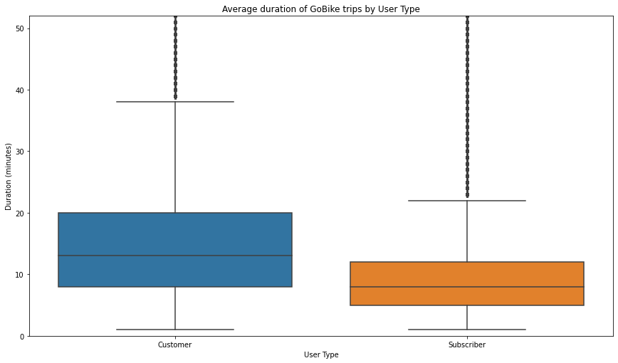

#### Trip duration by gender

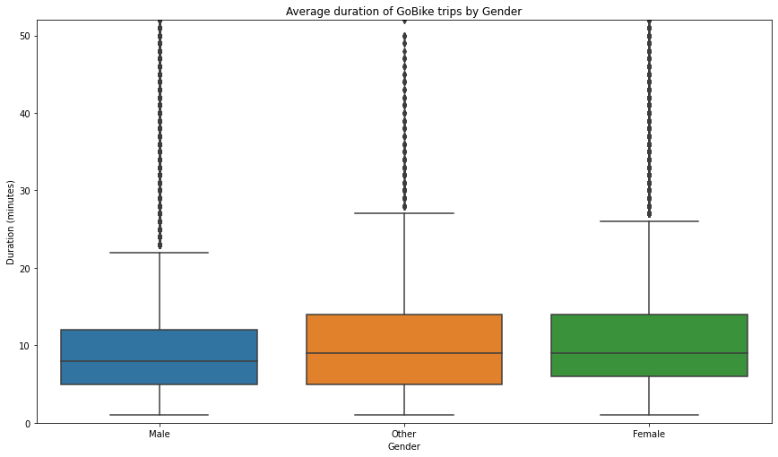

#### Most common time of day for trips by gender

As we saw in a previous analysis, both genders have trip start times that coincide with AM and PM commutes. For men, there appear to be small increases in usage throughout the middle of the day. Perhaps to run errands or grab lunch.

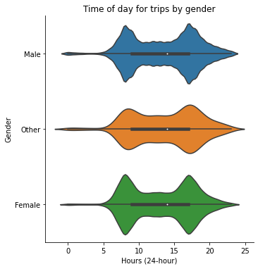

The relationships observed in the bivariate exploration were interesting. The basis of this analysis was to see the impact of the data when the relationship to user type was introduced. The largest discrepancies were regarding trip duration between customers and subscribers, as well as how age group or gender might impact trip duration. The data showed that trip duration is much longer with customers, not subscribers. In addition, the oldest age group of 56-75 take the longest trips averaging just over 12 minutes.

We learned that "other" is comprised of mostly 18-35 year olds who take the longest trips out of all other categories. This is interesting for several reasons, one of which being that this is contrary to any conclusions made that older riders take longer trips. As well, it is known that younger generations are more conscious about gender diversity and inclusion. Therefore, it is possible the absence of additional options is causing users to select "other".

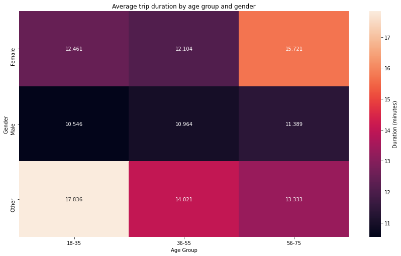

## Conclusions

The insights gathered from the analysis present some opportunities for GoBike to capitalize on:

- Men are the majority of GoBike users so more resources can be allocated towards male subscribers or upselling male customers to become subscribers
- Ensure there is enough supply of GoBikes during peak times of 8AM and 5PM. Consider a small surcharge during these times or when supply is low
- Consider targeting the youngest age group of 18-35 "other" users who seem to take the longest trips. This could involve finding out what stations they start and end their trips at most frequently
- Remove "other" and include additional gender options to allow for more finite analysis in the future